# Ch13: Grid search

## Introduction

This chapter focuses on using the grid search method to evaluate a number of hyperparameter values a priori.

```r
library(pacman)
p_load(tidyverse, tidymodels, broom, splines, janitor, patchwork,
       tidyposterior, rstanarm)

data(ames, package = "modeldata")
ames <- ames %>%
  clean_names() %>%
  mutate(sale_price = log10(sale_price))

# Split and read workflows
set.seed(123)
ames_split <- initial_split(ames, prop = 0.8, strata = sale_price)
ames_train <- training(ames_split)
ames_test <- testing(ames_split)

lm_workflow <- readRDS("../data/ames_lm_workflow.Rds")
lm_fit <- readRDS("../data/ames_lm_fit.Rds")
ames_recipe <- readRDS("../data/ames_recipe.Rds")
```

## Regular and non-regular grids

Regular grids are combinations of separate sets of values. These can easily be creating using `crossing()`. One of the benefits of this strategy is that we can easily see the relationships between the different variables and their combinations.

| hidden_units | penalty | epochs |
| --- | --- | --- |
| 1 | 0.0 | 100 |
| 1 | 0.0 | 200 |
| 1 | 0.1 | 100 |
| 1 | 0.1 | 200 |
| 2 | 0.0 | 100 |
| 2 | 0.0 | 200 |
| 2 | 0.1 | 100 |
| 2 | 0.1 | 200 |
| 3 | 0.0 | 100 |
| 3 | 0.0 | 200 |

[output cut: 2 more lines]

Irregular grids can also be used and include more complex designs to balance the need to explore sufficient parameter space while minimizing overlapping values.

## Evaluating the grid

In order to values in the tuning process, we need to use subsets of the data that were not used for training– that is, we need quasi holdout sets, or the assessment sets created in the validation split. We’ll use the `cells` data set, which consists of imaging measurements on breast cancer cells.

```r
# Build the workflow
(mlp_workflow <- workflow() %>%
  add_model(mlp_spec) %>%
  add_recipe(mlp_recipe))
```

```
══ Workflow ═══════════════════════════════════════════════════════
Preprocessor: Recipe
Model: mlp()

── Preprocessor ───────────────────────────────────────────────────
4 Recipe Steps

• step_YeoJohnson()
• step_normalize()
• step_pca()
• step_normalize()

── Model ──────────────────────────────────────────────────────────
Single Layer Neural Network Specification (classification)

Main Arguments:
  hidden_units = tune()
  penalty = tune()
  epochs = tune()

Engine-Specific Arguments:
  trace = 0

Computational engine: nnet
```

```r
(mlp_param <- mlp_workflow %>%
   parameters() %>%
   update(epochs = epochs(c(50, 200)),
          num_comp = num_comp(c(0, 40)))
)
```

```
Collection of 4 parameters for tuning

   identifier         type    object
 hidden_units hidden_units nparam[+]
      penalty      penalty nparam[+]
       epochs       epochs nparam[+]
     num_comp     num_comp nparam[+]
```

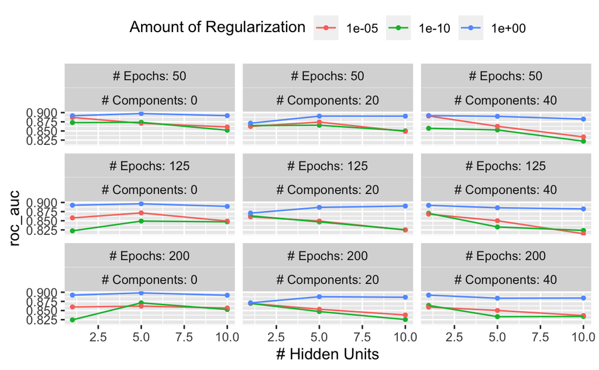

| hidden_units | penalty | epochs | num_comp | .metric | mean | n | std_err | .config |
| --- | --- | --- | --- | --- | --- | --- | --- | --- |
| 5 | 1 | 200 | 0 | roc_auc | 0.8981978 | 10 | 0.006974754 | Preprocessor1_Model26 |
| 5 | 1 | 50 | 0 | roc_auc | 0.8975561 | 10 | 0.007204507 | Preprocessor1_Model08 |
| 5 | 1 | 125 | 0 | roc_auc | 0.8964694 | 10 | 0.006245597 | Preprocessor1_Model17 |
| 1 | 1 | 125 | 0 | roc_auc | 0.8924202 | 10 | 0.006931615 | Preprocessor1_Model16 |
| 1 | 1 | 200 | 0 | roc_auc | 0.8921520 | 10 | 0.006950449 | Preprocessor1_Model25 |

## Finalizing the model

```r
# Finalize workflow
(final_mlp_workflow <- mlp_workflow %>%
  finalize_workflow(logistic_param))
```

```
══ Workflow ══════════════════════════════════════════════════════════════
Preprocessor: Recipe
Model: mlp()

── Preprocessor ──────────────────────────────────────────────────────────
4 Recipe Steps

• step_YeoJohnson()
• step_normalize()
• step_pca()
• step_normalize()

── Model ─────────────────────────────────────────────────────────────────
Single Layer Neural Network Specification (classification)

Main Arguments:
  hidden_units = 1
  penalty = 1
  epochs = 125

Engine-Specific Arguments:
  trace = 0

Computational engine: nnet
```

```r
# Note, fit final model to the entire training set
(final_mlp_fit <- final_mlp_workflow %>%
  fit(cells))
```

```
══ Workflow [trained] ════════════════════════════════════════════════════
Preprocessor: Recipe
Model: mlp()

── Preprocessor ──────────────────────────────────────────────────────────
4 Recipe Steps

• step_YeoJohnson()
• step_normalize()
• step_pca()
• step_normalize()

── Model ─────────────────────────────────────────────────────────────────
a 56-1-1 network with 59 weights
inputs: angle_ch_1 area_ch_1 avg_inten_ch_1 avg_inten_ch_2 avg_inten_ch_3 avg_inten_ch_4 convex_hull_area_ratio_ch_1 convex_hull_perim_ratio_ch_1 diff_inten_density_ch_1 diff_inten_density_ch_3 diff_inten_density_ch_4 entropy_inten_ch_1 entropy_inten_ch_3 entropy_inten_ch_4 eq_circ_diam_ch_1 eq_elli…
output(s): ..y
options were - entropy fitting  decay=1
```

## Tools for efficient grid search

By default, the `tune_()` functions can parallelize over the resamples, not the different configurations of the model tuning parameters. However, we can achieve the desired effect to loop over both the resamples and the tuning configurations using `crossing()`. However, the potential downside here is that if the splitting of the data and the pre-processing steps are computationally expensive, the process may slow considerably. The other downside with the latter method is that work is repeated (i.e., the same computations are performed multiple times).